# Unicef Metadata

Child punishment Support

Author

Nesteha Sherwa

Published

April 27, 2025

[figure not shown]

## The Use of Child Physical Punishment in Upbringing and Its Link to Economic Development

Child punishment as a method of raising has been widely debated across cultures and countries . Some countries view it as a necessary tool for raising and teaching discipline, while others consider it harmful to a child’s development. We will discover weather countries with higher support for physical punishment often have lower GDP per capita, within the countries is there a specific gender who is more likely use this method.

## Life Expectancy Growth vs. GDP per Capita

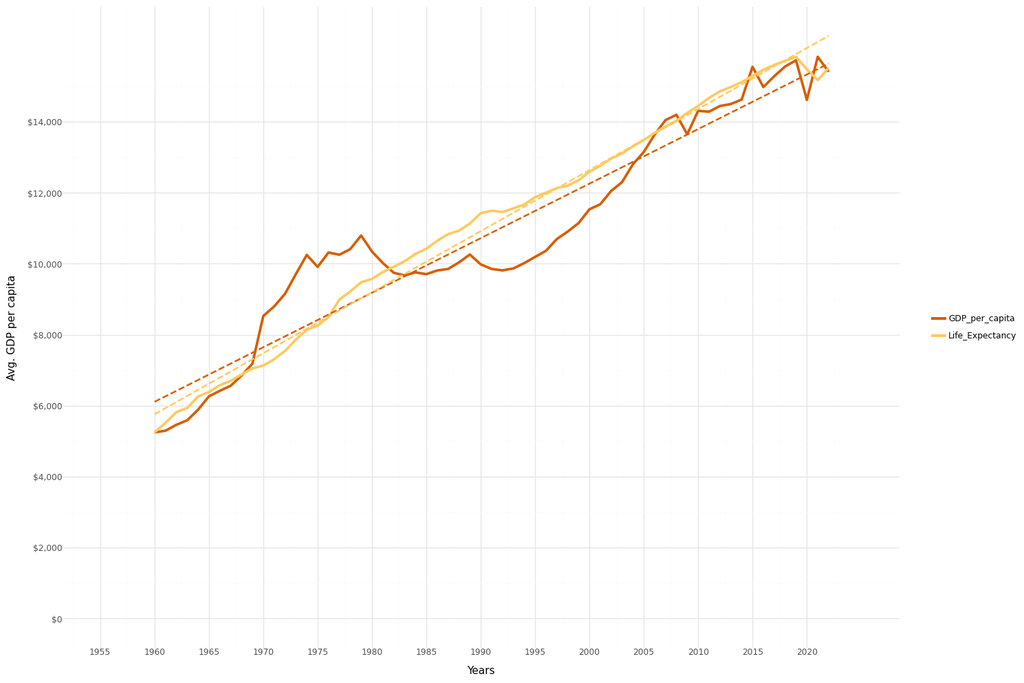

```python
import pandas as pd
from plotnine import *
from google.colab import drive



# Load and clean data
file_path = "/content/drive/MyDrive/Colab Notebooks/report/LifeExpectancyGrowthvsGDPperCapita_unicef_m_data.csv"
df = pd.read_csv(file_path)

# Drop rows with missing values in key columns
df = df.dropna(subset=[
    "GDP per capita (constant 2015 US$)",
    "Life expectancy at birth, total (years)",
    "Year of Year"
])

# Group by year and average the values
avg_df = df.groupby("Year of Year").agg({
    "GDP per capita (constant 2015 US$)": "mean",
    "Life expectancy at birth, total (years)": "mean"
}).reset_index()

# Rename columns for easier access
avg_df.columns = ["Year", "GDP_per_capita", "Life_Expectancy"]

# Reshape to long format
long_df = pd.melt(
    avg_df,
    id_vars="Year",
    value_vars=["GDP_per_capita", "Life_Expectancy"],
    var_name="Measure",
    value_name="Value"
)


# # Separate data for dual-axis simulation
long_gdp = long_df[long_df["Measure"] == "GDP_per_capita"].copy()
long_life = long_df[long_df["Measure"] == "Life_Expectancy"].copy()

# # Normalize Life Expectancy to match GDP scale range for visual dual-axis
life_min, life_max = long_life["Value"].min(), long_life["Value"].max()
gdp_min, gdp_max = long_gdp["Value"].min(), long_gdp["Value"].max()

scale_factor = (gdp_max - gdp_min) / (life_max - life_min)
offset = gdp_min - life_min * scale_factor
long_life["Value"] = long_life["Value"] * scale_factor + offset

# Combine adjusted data
combined_df = pd.concat([long_gdp, long_life])

# Plot using plotnine
graph = (
    ggplot(combined_df, aes(x="Year", y="Value", color="Measure")) +
    geom_line(size=1.5) +
    geom_smooth(method='lm', linetype="dashed", se=False) +


     scale_color_manual(
        values={
            "GDP_per_capita": "#D55E00",        # burnt orange
            "Life_Expectancy": "#FFC95F"        # yellow
        }
    ) +
#scale_color_manual(values=colors) +
    scale_y_continuous(
        name="Avg. GDP per capita",
        labels=lambda l: [f"${int(x):,}" for x in l],
        limits=(0, None),
        breaks=range(0, int(combined_df["Value"].max()) + 1, 2000)

    ) +
    scale_x_continuous(
        name="Years",
        limits=(1955, 2025),
        breaks=range(1950, 2025, 5)
 ) +
    labs(

        x="Years"
    ) +
    theme_minimal() +
    theme(
        legend_title=element_blank(),
        plot_title=element_text(size=14, weight='bold', ha='center')

    )
)

import matplotlib.pyplot as plt
fig = graph.draw()
fig.set_size_inches(15, 10)
fig
```

This visualization underscores the positive correlation between economic development and improvements in public health over time.

## Top 6 countries with Highest GDP per capita (1960–2023)

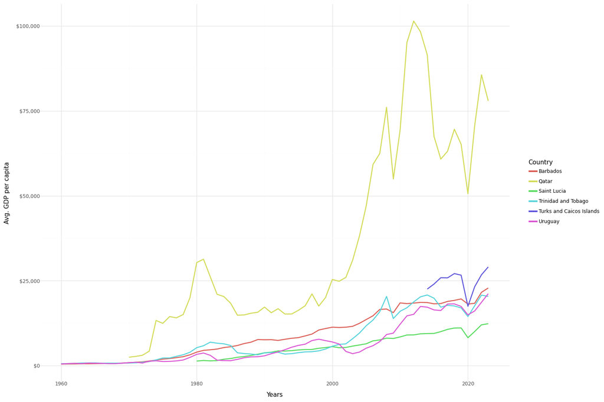

```python
import pandas as pd
from plotnine import *

# Load top GDP countries data
df = pd.read_csv("/content/drive/MyDrive/Colab Notebooks/report/Highest_GDP_per_capita_data.csv")


# Plot line chart by country
graph =(
    ggplot(df, aes(x="Year of Year", y="Avg. GDP per capita", color="Country")) +
    geom_line(size=1) +
    labs(

        x="Years",
        y="Avg. GDP per capita"
    ) +

    scale_y_continuous
     (labels=lambda l: [f"${int(x):,}" for x in l]) +

    theme_minimal()

)
# graph.save("/mnt/data/highest_gdp_per_capita_plot.png", width=12, height=6, dpi=300)
graph.draw()
import matplotlib.pyplot as plt
fig = graph.draw()
fig.set_size_inches(15, 10)
fig
```

This graph showcases the six countries with the highest average GDP per capita over time. Qatar shows a significant rise, peaking above $100,000 before fluctuating. Other countries such as Uruguay, Barbados, and Trinidad & Tobago exhibit steady growth but remain at lower levels compared to Qatar.

The overall trend indicates that wealthier nations have experienced continuous economic growth, with some volatility.

## Bottom 5 countries with Lowest GDP per capita (1960–2023)

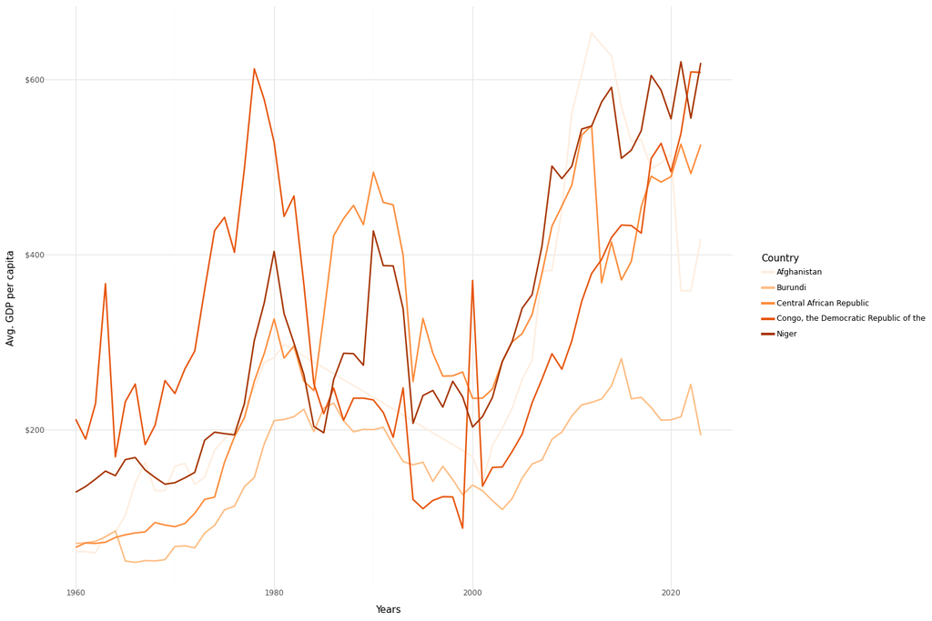

```python
import pandas as pd
from plotnine import *

# Load GDP per capita time-series data
df = pd.read_csv("/content/drive/MyDrive/Colab Notebooks/report/Lowest GDP per capita_data.csv")

# Define custom shades of brown for consistent gradient look
shades = ["#feedde", "#fdbe85", "#fd8d3c", "#e6550d", "#a63603"]

# Ensure order for consistency if needed
df["Country"] = pd.Categorical(df["Country"], categories=sorted(df["Country"].unique()), ordered=True)

# Plot line chart
graph = (
    ggplot(df, aes(x="Year of Year", y="Avg. GDP per capita", color="Country")) +
    geom_line(size=1) +
    scale_color_manual(values=shades) +
    labs(

        x="Years",
        y="Avg. GDP per capita"
    ) +
    scale_y_continuous(labels=lambda l: [f"${int(x):,}" for x in l]) +
    theme_minimal()

)

# Save to file
# graph.save("/mnt/data/lowest_gdp_per_capita_plot.png", width=12, height=10, dpi=300)
graph.draw()
import matplotlib.pyplot as plt
fig = graph.draw()
fig.set_size_inches(15, 10)
fig
```

This line chart displaying the GDP per capita trends of the five countries with the lowest GDP per capita from 1960 to 2023. The y-axis represents the average GDP per capita in USD, while the x-axis represents the years from 1960 to 2023.

The five countries represented are Afghanistan, Burundi, Central African Republic, Democratic Republic of the Congo, and Niger. GDP per capita has fluctuated significantly over time, with some periods showing sharp increases or declines. There is an overall upward trend in GDP per capita for most of the countries, although the levels remain low.

In the next graph ,we will compare the relationship of high GDP countries and the different genders support.

## Male vs. female perspectives based on High GDP per capita

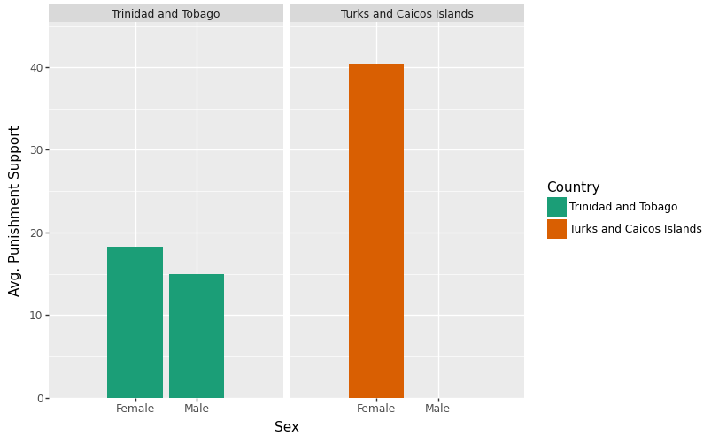

```python
import pandas as pd
from plotnine import *

# Load preprocessed high GDP gender data
df = pd.read_csv("/content/drive/MyDrive/Colab Notebooks/report/MaleFemale_HighGDP_Corrected.csv")

# Plot bar chart
graph = (
    ggplot(df, aes(x="Sex", y="Avg. Obs Value", fill="Country")) +
    geom_col(position="dodge") +
    facet_wrap("~Country") +
    scale_fill_brewer(type="qual", palette="Dark2") +
    scale_y_continuous(expand=(0, 0), limits=(0, df["Avg. Obs Value"].max() + 5)) +
    scale_x_discrete(expand=(0.5, 0)) +  # tighter x spacing but not completely zero

    labs(

        y="Avg. Punishment Support"
    )


)

graph.draw()
import matplotlib.pyplot as plt
fig = graph.draw()
fig.set_size_inches(8, 5)
fig
```

The bar chart shows that in Trinidad and Tobago, support for child physical punishment is higher among females than males but remains relatively low overall, while in the Turks and Caicos Islands, only females are represented, with significant support.

In the next graph ,we will compare the relationship of low GDP countries and the different genders support.

## Male vs. Female perspectives based on Low GDP per capita

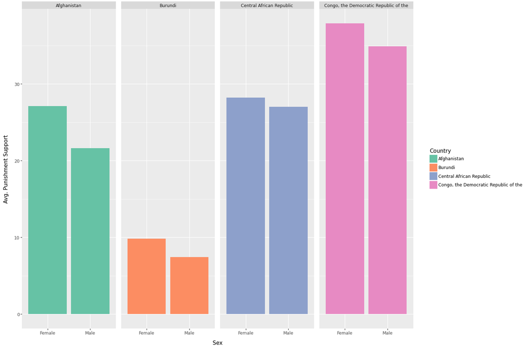

```python
import pandas as pd
from plotnine import *

# Load preprocessed low GDP gender data
df = pd.read_csv("/content/drive/MyDrive/Colab Notebooks/report/MaleFemale (Low  GDP Countries)_data.csv")

# Plot bar chart
graph = (
    ggplot(df, aes(x="Sex", y="Avg. Obs Value", fill="Country")) +
    geom_col(position="dodge") +
    facet_wrap("~Country",
  nrow = 1,
  ncol = 4)+
  scale_fill_brewer(type='qual', palette='Set2') +

scale_y_continuous(expand=(0, 0), limits=(0, df["Avg. Obs Value"].max() + 5)) +
    scale_x_discrete(expand=(0.5, 0)) +  # tighter x spacing but not completely zero
    labs(

        y="Avg. Punishment Support"
    )


)
graph.draw()
import matplotlib.pyplot as plt
fig = graph.draw()
fig.set_size_inches(15, 10)
fig
```

The bar chart indicates that support for child physical punishment is generally high in low-GDP countries, with variations between genders.

In Afghanistan and the Democratic Republic of the Congo, both males and females show strong support, with females slightly more supportive. In Burundi, support is low but slightly higher among females, while in the Central African Republic, both genders show nearly equal support.

The child punishment support in low-GDP nations is likely influenced by cultural norms, lack of awareness about alternative raising methods, and limited education on child rights, driven by traditional beliefs and socio-economic challenges